# Working with Big Data

David Kane

This month, the [CenSoc Project](https://censoc.berkeley.edu/) at Berkeley released the first version of their individual-level data sets with information on almost everyone in the 1940 U.S. Census. The data is available to us. Today’s project is to work with Big Data for real. (If you want to spend more time on machine learning, go through the examples in chapter 14.)

Fill out [this form](https://censoc-download.demog.berkeley.edu/) to access the data. You should receive an e-mail with a link to a page [like this one](https://censoc-download.demog.berkeley.edu/Data/Qm958Kq901/). (Do not use that page.) Download just the censoc_dmf_v1.zip file. Unzip it and place the `censoc_dmf_v1.csv` in your project. (Do not check this in to Github. It is too big.)

## Scene 1

- Read in the data into a tibble called `raw`. Make sure to use the `col_types` argument so that you code does not produce aesthetically offensive messages.
- Be professional. Give your R code chunks names. Use `cache=TRUE` as a code chunk option for any chunk that takes a long time to run.
- Once you have the data, take a look. There is at least one bad row. Find it and change your code so that it is not read in to `raw`.

```r
# There are several reasonable ways of dealing with zip'd data. One is to do
# things by-hand, placing the new directory someplace sensible. Another is to
# have the code start with the zipped file. This is good because the less times
# that you do anything by hand the better. But it is annoying because you have
# to design your script so that you don't repeat a step that has already
# happened. For now, I will just comment out unzip(). But, if this were updated
# each day, I would handle this programmatically.

# unzip("censoc_dmf_v1.zip")

raw <- read_csv("censoc_dmf_v1.csv",
                col_types = cols(HISTID = col_character(),
                                 byear = col_double(),
                                 bmonth = col_double(),
                                 dyear = col_double(),
                                 dmonth = col_double(),
                                 death_age = col_double(),
                                 weight = col_double())) %>%
  filter(! bmonth == 0)
```

- How many rows (individual men) do we have in the data? Big data!

```r
raw
```

```
## # A tibble: 5,703,273 x 7
##    HISTID                             byear bmonth dyear dmonth death_age weight
##    <chr>                              <dbl>  <dbl> <dbl>  <dbl>     <dbl>  <dbl>
##  1 DA30814D-7482-42DC-95BE-54FB704C5…  1912     12  1975      2        62  NA
##  2 1862987D-50DB-43DB-BB35-249697C34…  1917      3  2004      6        87   5.05
##  3 EF6E008D-A3B7-4041-8CFF-BAE31CBA7…  1897      5  1983      8        86   4.83
##  4 398B26CE-BE06-409B-B923-2F61A8F76…  1920     10  1982      1        61  NA
##  5 C2CADB08-7003-48EF-9384-05D8E7682…  1929      8  1986      3        56  NA
##  6 E01891C1-7392-48B8-8EE7-9A6175D69…  1912      2  1984     12        72   5.65
##  7 0334CC87-7897-4DE1-9D2B-DAF127E42…  1905      2  1984      6        79   5.20
##  8 4514954B-7C0E-4C1F-A787-F4E0641AF…  1930      1  1977     12        47  NA
##  9 2A297C03-A640-42ED-AF68-009A93A51…  1907     12  1986      3        78   4.42
## 10 03C2ABC5-5A5C-457A-AE1E-7A84A131A…  1921      2  2002      1        80   4.71
## # … with 5,703,263 more rows
```

- Consider the oldest man in the dataset. (All the observation are male.) What year was he born in?

```r
# Extreme ages are uncommon. 123 seems very old, especially for someone born in
# the 1800's, but who knows?

raw %>%
  arrange(desc(death_age))
```

```
## # A tibble: 5,703,273 x 7
##    HISTID                             byear bmonth dyear dmonth death_age weight
##    <chr>                              <dbl>  <dbl> <dbl>  <dbl>     <dbl>  <dbl>
##  1 38BD2A00-D08E-449C-BB3D-B8C6F1B5C…  1860      6  1984      4       123     NA
##  2 DE89CE63-6C35-4805-B6DA-76FBF2F5C…  1854      7  1976      1       121     NA
##  3 F14F0AB7-DC23-454B-972E-54307F3A0…  1862     12  1982      1       119     NA
##  4 A7AA031D-E499-4527-A166-C973DFFB2…  1866     10  1985      9       118     NA
##  5 E2D17003-6409-4836-BFDD-25433D072…  1880      2  1997      3       117     NA
##  6 BE0B03E1-EA5E-40A2-AC31-7394BAFA9…  1858     12  1976      2       117     NA
##  7 F98680F5-23ED-4CB9-9EAC-F1E0DB583…  1889      5  2005     11       116     NA
##  8 4C195D16-5555-466B-A7BE-A23D6182B…  1865      1  1980      9       115     NA
##  9 94BE4E05-E633-427F-854B-5759BE985…  1882      3  1997     12       115     NA
## 10 E4E03ECC-3E52-4343-A560-623FCBC2B…  1863      6  1978     10       115     NA
## # … with 5,703,263 more rows
```

- Calculate the average age at death by birth year. What two years have the highest average? Why? Without looking can you guess which years have the lowest average?

```r
raw %>%
  group_by(byear) %>%
  summarize(avg_death_age = mean(death_age)) %>%
  top_n(2, avg_death_age)
```

```
## # A tibble: 2 x 2
##   byear avg_death_age
##   <dbl>         <dbl>
## 1  1854           121
## 2  1860           123
```

- Which four months have the highest number of deaths? Why? What does that suggest about the influence of global warming on mortality?

```r
# More people die in cold weather. There is some dispute about why this is the
# case. First, cold is just tough on old people. Second, pneumonia, flu and
# other communicable diseases seem to spread more easily in colder weather.

# Fewer people die in warmer winters than in colder winters. So, if Chicago
# winters were warming, because of Global Warming, fewer people would die.

raw %>%
  group_by(dmonth) %>%
  summarize(total = n()) %>%
  top_n(4, total)
```

```
## # A tibble: 4 x 2
##   dmonth  total
##    <dbl>  <int>
## 1      1 546545
## 2      2 482757
## 3      3 509655
## 4     12 513928
```

## Scene 2

This data set is not easy to work with because it has no dates. It just has months and years. Create a new variable, `death_date`, defined as the first day of the month when someone died, even though we don’t have exact day information. Drop all the variables except `death_date` and `death_age`. A smaller data set will be easier to work with. Call this new tibble `x`.

Hint: **lubridate** is a useful package. I used `ymd()`, with a little hackery, but there are other ways. Make a character and then convert it is one approach . . .

Create a plot like the [one on Piazza](https://piazza.com/class/k5y1jx0s5ibe1?cid=776) which shows a histogram of ages at death.

Don’t try to get this working on the whole data set at once. That takes forever. Create a small data set called `small` with about 10,000 rows randomly sampled from `x` first. Use `small` for everything. Then, when the plot looks good, use `x`.

```r
# Separating your data processing into different code chunks can be useful. Once
# you have read the data in once, you don't want to do it 50 more times.

x <- raw %>%
  mutate(death_date = ymd(paste(dyear, dmonth, "01", sep = "-"))) %>%
  select(death_date, death_age)

# There is no need to work with 5 million rows of data until you are use sure
# you code is working. Instead, get everything working with 10,000, and then go
# back. I use the small data set until things work, then switch in x.

small <- x %>%
  sample_n(10000)

z2 <- x %>%
  group_by(death_age) %>%
  summarize(deaths = n())
```

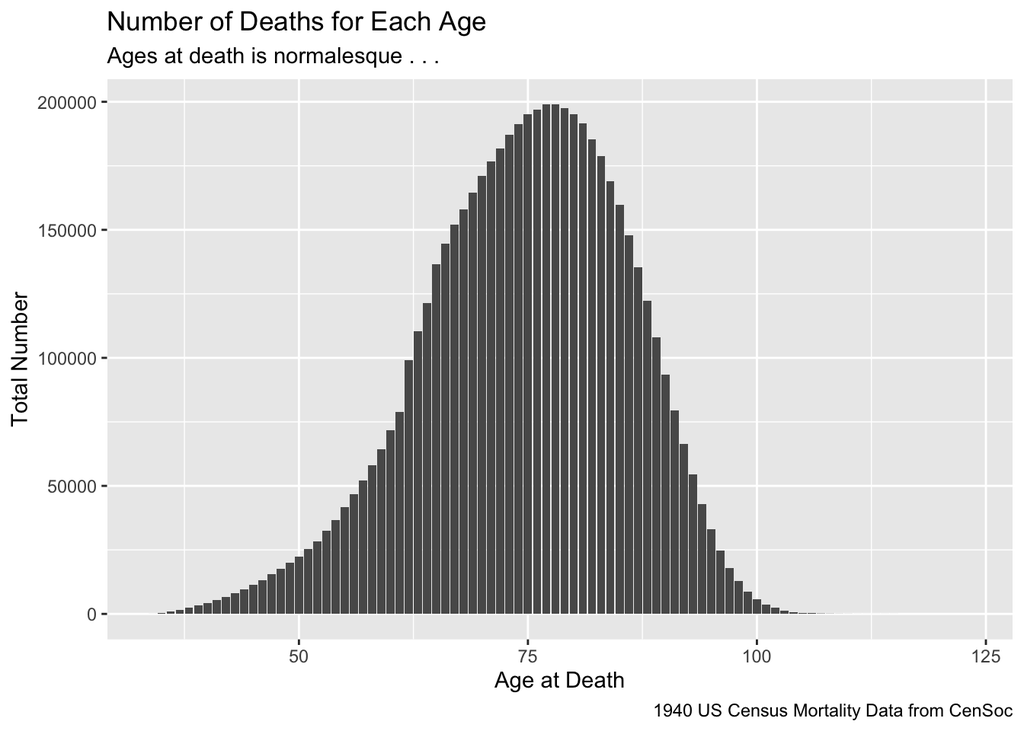

```r
sc2_p <- z2 %>%
  ggplot(aes(x = death_age, y = deaths)) +
    geom_col() +
    labs(x = "Age at Death",
         y = "Total Number",
         title = "Number of Deaths for Each Age",
         subtitle = "Ages at death is normalesque . . .",
         caption = "1940 US Census Mortality Data from CenSoc")

sc2_p
```

```r
# ggsave("scene2.jpg", sc2_p)
```

## Scene 3

Make a [cool animation](https://davidkane9.github.io/PPBDS/C-animation.html) with this data. First step is to build an interesting static graphic, using all your favorite **ggplot** tools. Then animate it in an interesting way. See the [one on Piazza](https://piazza.com/class/k5y1jx0s5ibe1?cid=776) for my example. Do something similar, or better!

Hint: Always work with small data first! Get that working and then use big data.

Hint: If you `group_by()` first, things go faster since you don’t want to manipulate 5 million rows unless you have to.

Although you can go back and grab `dmonth`, you don’t need to! You can work just with `x` and figure out the month by using the `month()` function.

```r
z3 <- x %>%
  group_by(death_date) %>%
  summarize(total = n(),
            avg_age = mean(death_age)) %>%
  mutate(season = ifelse(month(death_date) %in% c(10, 11, 12, 1, 2, 3), "Cold", "Warm")) %>%
  mutate(season = parse_factor(season, levels = c("Cold", "Warm")))

# Instead of making the plot with all the days that you have, make it for just a
# few dates, at least until you get things working. Remember that animations
# scale by the number of things being animated, which is the number of days in
# this case.

# filter(death_date > as.Date("2005-12-15")) %>%

# I tried to get transition_states() and shadow_mark() to work


sc3_p <- z3 %>%
  ggplot(aes(y = total, x = death_date, color = season)) +
    geom_point() +
    geom_line() +
    labs(x = "Date of Death",
         y = "Total",
         title = "Total Deaths Over Time",
         subtitle = "More deaths during cold weather",
         caption = "1940 US Census Mortality Data from CenSoc") +
    theme_minimal() +
    theme(panel.grid = element_blank(),
          panel.grid.major.y = element_line(color = "white"),
          panel.ontop = TRUE) +
    scale_fill_discrete(guide = guide_legend("Season")) +
    transition_reveal(death_date)


# anim_save("sc3.gif", sc3_p)
```

## Challenge Problem

Use this data and the [d3rain package](https://github.com/daranzolin/d3rain) to create a cool animation with this data. Perhaps birth years across the top. The rain falls down to either death years or to ages at death. Or something else. Impress us! Put your animation on Rpubs and leave a link on Piazza.